# 重賞レース予測レポート【レース終了】

作成日時: 2025/08/31 17:51:56

☞ [マニュアル(pdf)](https://ryutoro-galois.github.io/keiba-predictor/manual/manual.pdf)

☞ 過去5年の同一レース結果: [2024年](https://ryutoro-galois.github.io/keiba-predictor/report/PredResult_2024y_raceDate_20240901_20240901.html), [2023年](https://ryutoro-galois.github.io/keiba-predictor/report/PredResult_2023y_raceDate_20230902_20230903.html), [2022年](https://ryutoro-galois.github.io/keiba-predictor/report/PredResult_2022y_raceDate_20220903_20220904.html), [2021年](https://ryutoro-galois.github.io/keiba-predictor/report/PredResult_2021y_raceDate_20210904_20210905.html), [2020年](https://ryutoro-galois.github.io/keiba-predictor/report/PredResult_2020y_raceDate_20200905_20200906.html)

☞ 過去4週間の別レース結果: [1週前(8/24)](https://ryutoro-galois.github.io/keiba-predictor/report/PredResult_2025y_raceDate_20250824_20250824.html), [2週前(8/16-17)](https://ryutoro-galois.github.io/keiba-predictor/report/PredResult_2025y_raceDate_20250816_20250817.html), [3週前(8/9-10)](https://ryutoro-galois.github.io/keiba-predictor/report/PredResult_2025y_raceDate_20250809_20250810.html), [4週前(8/3)](https://ryutoro-galois.github.io/keiba-predictor/report/PredResult_2025y_raceDate_20250803_20250803.html)

☞ netkeiba: [新潟記念(GⅢ)](https://race.netkeiba.com/race/result.html?race_id=202504030411&rf=race_submenu), [中京２歳ステークス(GⅢ)](https://race.netkeiba.com/race/result.html?race_id=202507040411&rf=race_submenu)

☞ レース結果(csv): [8/30-31](https://ryutoro-galois.github.io/keiba-predictor/csv/race_result_20250830_20250831.csv)

## 【レース結果(1)】人気と着順の関係

### 【新潟記念(2025/08/31(日))】

【新潟記念(GⅢ)】  
2025/08/31(日), 04_新潟, 芝左外2000m

[interactive chart not shown]

### 【中京２歳ステークス(2025/08/31(日))】

【中京2歳ステークス(GⅢ)】  
2025/08/31(日), 07_中京, 芝1400m

[interactive chart not shown]

## 【レース結果(2)】コーナー通過順位

### 【新潟記念(2025/08/31(日))】

【新潟記念(GⅢ)】  
2025/08/31(日), 04_新潟, 芝左外2000m

[interactive chart not shown]

### 【中京２歳ステークス(2025/08/31(日))】

【中京2歳ステークス(GⅢ)】  
2025/08/31(日), 07_中京, 芝1400m

[interactive chart not shown]

## 0. 推し馬予測 (AI予測)

### 【新潟記念(GⅢ) 2025/08/31(日)】

- 本命(◎): 1-3着内確率(勝負強さ)が1位の馬
- 対抗(◯): 1-3着内確率が2-N位(20%程度以上)の中で予測タイムが最も速い馬
- 3番手(▲): 1-3着内確率が2-N位(20%程度以上)のでダークホース確率が最も高い馬
- 穴: ダークホース確率が上位1-M位(40%程度以上)の中で1-3着内確率が最も高い馬

| 推し馬 | 枠番 | 馬番 | 人気 | オッズ | 馬名 | 騎手 | 調教師 | 予測タイム(sec) | 1_順位 | 1-3着内確率(%) | 2_順位 | ﾀﾞｰｸﾎｰｽ確率(%) | 3_順位 |
| --- | --- | --- | --- | --- | --- | --- | --- | --- | --- | --- | --- | --- | --- |
| 本命(◎) | 1 | 1 | 3 | 4.7 | ブレイディヴェーグ | 津村明秀 | 宮田敬介 | 124.1 | 6.0 | 28.2 | 1 | 0.8 | 11 |
| 対抗(◯) | 5 | 9 | 7 | 22.8 | ディープモンスター | 菅原明良 | 池江泰寿 | 117.5 | 2.5 | 24.5 | 3 | 1.4 | 10 |
| 3番手(▲) | 8 | 15 | 1 | 3.0 | エネルジコ | Ｃ．ルメール | 高柳瑞樹 | 117.5 | 2.5 | 22.0 | 5 | 0.6 | 12 |
| 穴 | 8 | 16 | 9 | 25.8 | ヴェローチェエラ | 丸山元気 | 須貝尚介 | 128.5 | 11.0 | 17.2 | 6 | 56.5 | 3 |

### 【中京2歳ステークス(GⅢ) 2025/08/31(日)】

- 本命(◎): 1-3着内確率(勝負強さ)が1位の馬
- 対抗(◯): 1-3着内確率が2-N位(20%程度以上)の中で予測タイムが最も速い馬
- 3番手(▲): 1-3着内確率が2-N位(20%程度以上)のでダークホース確率が最も高い馬
- 穴: ダークホース確率が上位1-M位(40%程度以上)の中で1-3着内確率が最も高い馬

| 推し馬 | 枠番 | 馬番 | 人気 | オッズ | 馬名 | 騎手 | 調教師 | 予測タイム(sec) | 1_順位 | 1-3着内確率(%) | 2_順位 | ﾀﾞｰｸﾎｰｽ確率(%) | 3_順位 |
| --- | --- | --- | --- | --- | --- | --- | --- | --- | --- | --- | --- | --- | --- |
| 本命(◎) | 6 | 8 | 2 | 7.1 | パープルガーネット | 吉村誠之助 | 森一誠 | 86.9 | 13.0 | 23.6 | 1 | 1.4 | 12 |
| 対抗(◯) | 2 | 2 | 3 | 7.9 | マイケルバローズ | 岩田望来 | 上村洋行 | 86.8 | 10.0 | 22.3 | 2 | 1.7 | 11 |
| 3番手(▲) | 1 | 1 | 5 | 12.6 | タマモイカロス | 田口貫太 | 藤岡健一 | 86.8 | 11.5 | 19.3 | 4 | 2.0 | 7 |
| 穴 | 4 | 5 | 8 | 36.8 | エンヴィーミー | 松若風馬 | 森秀行 | 86.6 | 4.5 | 9.7 | 8 | 34.8 | 4 |

## 1. 予測チャート (タイム/勝負強さ)

### 【新潟記念(GⅢ)】

2025/08/31(日), 04_新潟, 芝左外2000m

[interactive chart not shown]

### 【中京2歳ステークス(GⅢ)】

2025/08/31(日), 07_中京, 芝1400m

[interactive chart not shown]

## 2. オッズモニタリング (毎時)

### 【新潟記念】

[interactive chart not shown]

### 【中京２歳ステークス】

[interactive chart not shown]

## 3. 出馬表

### 【新潟記念 2025/08/31(日) 】

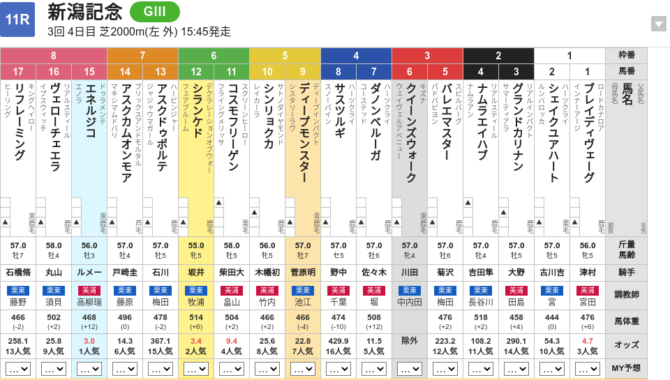

### 【中京２歳ステークス 2025/08/31(日) 】

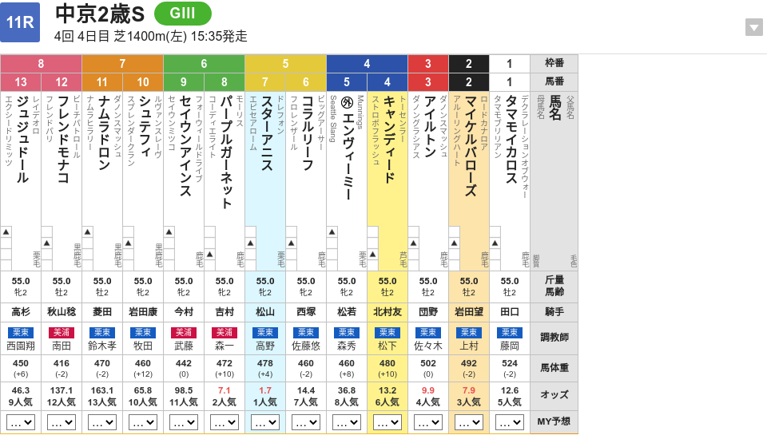

## 4. 単勝予測結果

### 【新潟記念(GⅢ) 2025/08/31(日)】

| 枠番 | 馬番 | 人気 | オッズ | 馬名 | 騎手 | 調教師 | 予測タイム(sec) | 1_順位 | 1-3着内確率(%) | 2_順位 | ﾀﾞｰｸﾎｰｽ確率(%) | 3_順位 |
| --- | --- | --- | --- | --- | --- | --- | --- | --- | --- | --- | --- | --- |
| 1 | 1 | 3 | 4.7 | ブレイディヴェーグ | 津村明秀 | 宮田敬介 | 124.1 | 6.0 | 28.2 | 1 | 0.8 | 11 |
| 1 | 2 | 10 | 54.3 | シェイクユアハート | 古川吉洋 | 宮徹 | 130.5 | 14.0 | 6.2 | 14 | 11.9 | 8 |
| 2 | 3 | 14 | 290.1 | グランドカリナン | 大野拓弥 | 田島俊明 | 127.7 | 8.0 | 8.9 | 10 | 63.0 | 2 |
| 2 | 4 | 11 | 108.2 | ナムラエイハブ | 吉田隼人 | 長谷川浩大 | 128.5 | 10.0 | 6.5 | 13 | 49.2 | 4 |
| 3 | 5 | 12 | 223.2 | バレエマスター | 菊沢一樹 | 梅田智之 | 126.2 | 7.0 | 7.6 | 12 | 47.2 | 5 |
| 4 | 7 | 5 | 11.5 | ダノンベルーガ | 佐々木大輔 | 堀宣行 | 117.5 | 2.5 | 25.4 | 2 | 0.6 | 14 |
| 4 | 8 | 16 | 429.9 | サスツルギ | 野中悠太郎 | 千葉直人 | 127.9 | 9.0 | 8.5 | 11 | 70.4 | 1 |
| 5 | 9 | 7 | 22.8 | ディープモンスター | 菅原明良 | 池江泰寿 | 117.5 | 2.5 | 24.5 | 3 | 1.4 | 10 |
| 5 | 10 | 8 | 25.6 | シンリョクカ | 木幡初也 | 竹内正洋 | 118.6 | 5.0 | 16.9 | 7 | 1.4 | 9 |
| 6 | 11 | 4 | 9.4 | コスモフリーゲン | 柴田大知 | 畠山吉宏 | 128.6 | 12.0 | 22.1 | 4 | 0.6 | 13 |

[output cut: 6 more lines]

### 【中京2歳ステークス(GⅢ) 2025/08/31(日)】

| 枠番 | 馬番 | 人気 | オッズ | 馬名 | 騎手 | 調教師 | 予測タイム(sec) | 1_順位 | 1-3着内確率(%) | 2_順位 | ﾀﾞｰｸﾎｰｽ確率(%) | 3_順位 |
| --- | --- | --- | --- | --- | --- | --- | --- | --- | --- | --- | --- | --- |
| 1 | 1 | 5 | 12.6 | タマモイカロス | 田口貫太 | 藤岡健一 | 86.8 | 11.5 | 19.3 | 4 | 2.0 | 7 |
| 2 | 2 | 3 | 7.9 | マイケルバローズ | 岩田望来 | 上村洋行 | 86.8 | 10.0 | 22.3 | 2 | 1.7 | 11 |
| 3 | 3 | 4 | 9.9 | アイルトン | 団野大成 | 佐々木晶三 | 86.8 | 11.5 | 19.8 | 3 | 1.9 | 9 |
| 4 | 4 | 6 | 13.2 | キャンディード | 北村友一 | 松下武士 | 86.7 | 7.0 | 17.7 | 5 | 2.0 | 8 |
| 4 | 5 | 8 | 36.8 | エンヴィーミー | 松若風馬 | 森秀行 | 86.6 | 4.5 | 9.7 | 8 | 34.8 | 4 |
| 5 | 6 | 7 | 14.4 | コラルリーフ | 西塚洸二 | 佐藤悠太 | 86.6 | 2.0 | 14.1 | 7 | 1.8 | 10 |
| 5 | 7 | 1 | 1.7 | スターアニス | 松山弘平 | 高野友和 | 80.8 | 1.0 | 16.6 | 6 | 0.4 | 13 |
| 6 | 8 | 2 | 7.1 | パープルガーネット | 吉村誠之助 | 森一誠 | 86.9 | 13.0 | 23.6 | 1 | 1.4 | 12 |
| 6 | 9 | 11 | 98.5 | セイウンアインス | 今村聖奈 | 武藤善則 | 86.6 | 4.5 | 7.1 | 11 | 35.8 | 3 |
| 7 | 10 | 10 | 65.8 | シュテフィ | 岩田康誠 | 牧田和弥 | 86.6 | 4.5 | 7.4 | 10 | 33.4 | 5 |

[output cut: 3 more lines]

## 5. 人気と着順の乖離率推移

### 【新潟記念_1990y_2019y】

[interactive chart not shown]

### 【新潟記念_1990y_2019y】

| No | 開催年 | 不整合率(%) | 頭数 | 人気別着順(1-3位) | 人気別着順(全体) |
| --- | --- | --- | --- | --- | --- |
| 30 | 2019 | 43.7 | 18頭 | 2-6-8 | 2\|6\|8\|11\|3\|14\|4\|12\|15\|1\|5\|13\|9\|16\|17\|10\|18\|7 |
| 29 | 2018 | 45.3 | 13頭 | 1-6-13 | 1\|6\|13\|5\|10\|4\|3\|7\|9\|2\|11\|8\|12 |
| 28 | 2017 | 33.6 | 17頭 | 6-1-12 | 6\|1\|12\|10\|11\|3\|2\|5\|7\|15\|9\|8\|14\|4\|17\|13\|16 |
| 27 | 2016 | 34.5 | 18頭 | 2-1-9 | 2\|1\|9\|7\|4\|6\|16\|5\|11\|14\|12\|17\|15\|10\|13\|3\|18\|8 |
| 26 | 2015 | 76.0 | 18頭 | 6-9-13 | 6\|9\|13\|10\|14\|7\|5\|12\|3\|2\|15\|8\|18\|11\|4\|1\|16\|17 |
| 25 | 2014 | 39.6 | 18頭 | 1-5-3 | 1\|5\|3\|17\|11\|14\|7\|12\|13\|6\|4\|8\|10\|18\|9\|16\|15\|2 |
| 24 | 2013 | 49.6 | 14頭 | 10-8-7 | 10\|8\|7\|3\|1\|13\|12\|14\|2\|6\|5\|9\|11\|4 |
| 23 | 2012 | 45.6 | 18頭 | 7-9-8 | 7\|9\|8\|2\|11\|4\|1\|13\|6\|5\|14\|12\|17\|3\|16\|15\|9\|18 |
| 22 | 2011 | 52.0 | 11頭 | 5-9-3 | 5\|9\|3\|1\|7\|6\|8\|2\|11\|4\|10 |
| 21 | 2010 | 53.3 | 17頭 | 5-10-4 | 5\|10\|4\|2\|3\|1\|6\|15\|7\|12\|16\|17\|8\|13\|14\|11\|9 |

[output cut: 20 more lines]

## 6. 1-3番人気馬の着順分類予測

### 【新潟記念】

| 分類 | 凡例 | 発生確率(%) | 当該レース | 当該レースランク | 直近1年間 |
| --- | --- | --- | --- | --- | --- |
| 1: 1番人気のみ (1_pop1) | 1 \| * \| * | 17.1 | 1.50 | 1.50 | 0.00 |
| 4: 1,2番人気のみ (4_pop12) | 1 \| 2 \| * | 16.3 | 1.90 | 1.90 | 0.00 |
| 5: 1,3番人気のみ (5_pop13) | 1 \| 3 \| * | 14.1 | 0.99 | 0.99 | 0.00 |
| 8: 1,2,3番人気すべて着外 (8_darkhorse) | * \| * \| * | 14.1 | 0.49 | 0.49 | 0.00 |
| 2: 2番人気のみ (2_pop2) | 2 \| * \| * | 12.3 | 0.48 | 0.48 | 0.12 |
| 6: 2,3番人気のみ (6_pop23) | 2 \| 3 \| * | 9.8 | 0.00 | 0.00 | 0.00 |
| 3: 3番人気のみ (3_pop3) | 3 \| * \| * | 9.3 | 0.82 | 0.82 | 0.00 |
| 7: 1,2,3番人気すべて着内 (7_pop123) | 1 \| 2 \| 3 | 7.0 | 0.00 | 0.00 | 0.00 |

## 7. 3連複予測結果

### 【新潟記念(GⅢ) 2025/08/31(日)】

| 分類 | 馬番 | 枠番 | 人気 | 平均予測タイム(sec) | 1-3着内確率(%) | ﾀﾞｰｸﾎｰｽ確率(%) | 馬名 | 騎手 | 調教師 |
| --- | --- | --- | --- | --- | --- | --- | --- | --- | --- |
| 3: 3番人気のみ (3_pop3) | 1-7-9 | 1-4-5 | 3-5-7 | 119.70 | 1.76 | 0.00 | ブレイディヴェーグ \| ダノンベルーガ \| ディープモンスター | 津村明秀 \| 佐々木大輔 \| 菅原明良 | 宮田敬介 \| 堀宣行 \| 池江泰寿 |
| 3: 3番人気のみ (3_pop3) | 1-11-7 | 1-6-4 | 3-4-5 | 123.40 | 1.58 | 0.00 | ブレイディヴェーグ \| コスモフリーゲン \| ダノンベルーガ | 津村明秀 \| 柴田大知 \| 佐々木大輔 | 宮田敬介 \| 畠山吉宏 \| 堀宣行 |
| 5: 1,3番人気のみ (5_pop13) | 15-1-7 | 8-1-4 | 1-3-5 | 119.70 | 1.58 | 0.00 | エネルジコ \| ブレイディヴェーグ \| ダノンベルーガ | Ｃ．ルメール \| 津村明秀 \| 佐々木大輔 | 高柳瑞樹 \| 宮田敬介 \| 堀宣行 |
| 3: 3番人気のみ (3_pop3) | 1-11-9 | 1-6-5 | 3-4-7 | 123.40 | 1.53 | 0.00 | ブレイディヴェーグ \| コスモフリーゲン \| ディープモンスター | 津村明秀 \| 柴田大知 \| 菅原明良 | 宮田敬介 \| 畠山吉宏 \| 池江泰寿 |
| 5: 1,3番人気のみ (5_pop13) | 15-1-9 | 8-1-5 | 1-3-7 | 119.70 | 1.52 | 0.00 | エネルジコ \| ブレイディヴェーグ \| ディープモンスター | Ｃ．ルメール \| 津村明秀 \| 菅原明良 | 高柳瑞樹 \| 宮田敬介 \| 池江泰寿 |
| 5: 1,3番人気のみ (5_pop13) | 15-1-11 | 8-1-6 | 1-3-4 | 123.40 | 1.37 | 0.00 | エネルジコ \| ブレイディヴェーグ \| コスモフリーゲン | Ｃ．ルメール \| 津村明秀 \| 柴田大知 | 高柳瑞樹 \| 宮田敬介 \| 畠山吉宏 |
| 8: 1,2,3番人気すべて着外 (8_darkhorse) | 11-7-9 | 6-4-5 | 4-5-7 | 121.20 | 1.37 | 0.00 | コスモフリーゲン \| ダノンベルーガ \| ディープモンスター | 柴田大知 \| 佐々木大輔 \| 菅原明良 | 畠山吉宏 \| 堀宣行 \| 池江泰寿 |
| 1: 1番人気のみ (1_pop1) | 15-7-9 | 8-4-5 | 1-5-7 | 117.50 | 1.37 | 0.00 | エネルジコ \| ダノンベルーガ \| ディープモンスター | Ｃ．ルメール \| 佐々木大輔 \| 菅原明良 | 高柳瑞樹 \| 堀宣行 \| 池江泰寿 |
| 1: 1番人気のみ (1_pop1) | 15-11-7 | 8-6-4 | 1-4-5 | 121.20 | 1.24 | 0.00 | エネルジコ \| コスモフリーゲン \| ダノンベルーガ | Ｃ．ルメール \| 柴田大知 \| 佐々木大輔 | 高柳瑞樹 \| 畠山吉宏 \| 堀宣行 |
| 3: 3番人気のみ (3_pop3) | 1-7-16 | 1-4-8 | 3-5-9 | 123.37 | 1.23 | 0.00 | ブレイディヴェーグ \| ダノンベルーガ \| ヴェローチェエラ | 津村明秀 \| 佐々木大輔 \| 丸山元気 | 宮田敬介 \| 堀宣行 \| 須貝尚介 |

[output cut: 550 more lines]

### 【中京2歳ステークス(GⅢ) 2025/08/31(日)】

| 分類 | 馬番 | 枠番 | 人気 | 平均予測タイム(sec) | 1-3着内確率(%) | ﾀﾞｰｸﾎｰｽ確率(%) | 馬名 | 騎手 | 調教師 |
| --- | --- | --- | --- | --- | --- | --- | --- | --- | --- |
| 6: 2,3番人気のみ (6_pop23) | 8-2-3 | 6-2-3 | 2-3-4 | 86.83 | 1.04 | 0.00 | パープルガーネット \| マイケルバローズ \| アイルトン | 吉村誠之助 \| 岩田望来 \| 団野大成 | 森一誠 \| 上村洋行 \| 佐々木晶三 |
| 6: 2,3番人気のみ (6_pop23) | 8-2-1 | 6-2-1 | 2-3-5 | 86.83 | 1.02 | 0.00 | パープルガーネット \| マイケルバローズ \| タマモイカロス | 吉村誠之助 \| 岩田望来 \| 田口貫太 | 森一誠 \| 上村洋行 \| 藤岡健一 |
| 6: 2,3番人気のみ (6_pop23) | 8-2-4 | 6-2-4 | 2-3-6 | 86.80 | 0.93 | 0.00 | パープルガーネット \| マイケルバローズ \| キャンディード | 吉村誠之助 \| 岩田望来 \| 北村友一 | 森一誠 \| 上村洋行 \| 松下武士 |
| 2: 2番人気のみ (2_pop2) | 8-3-1 | 6-3-1 | 2-4-5 | 86.83 | 0.90 | 0.00 | パープルガーネット \| アイルトン \| タマモイカロス | 吉村誠之助 \| 団野大成 \| 田口貫太 | 森一誠 \| 佐々木晶三 \| 藤岡健一 |
| 7: 1,2,3番人気すべて着内 (7_pop123) | 7-8-2 | 5-6-2 | 1-2-3 | 84.83 | 0.87 | 0.00 | スターアニス \| パープルガーネット \| マイケルバローズ | 松山弘平 \| 吉村誠之助 \| 岩田望来 | 高野友和 \| 森一誠 \| 上村洋行 |
| 3: 3番人気のみ (3_pop3) | 2-3-1 | 2-3-1 | 3-4-5 | 86.80 | 0.85 | 0.00 | マイケルバローズ \| アイルトン \| タマモイカロス | 岩田望来 \| 団野大成 \| 田口貫太 | 上村洋行 \| 佐々木晶三 \| 藤岡健一 |
| 2: 2番人気のみ (2_pop2) | 8-3-4 | 6-3-4 | 2-4-6 | 86.80 | 0.82 | 0.00 | パープルガーネット \| アイルトン \| キャンディード | 吉村誠之助 \| 団野大成 \| 北村友一 | 森一誠 \| 佐々木晶三 \| 松下武士 |
| 2: 2番人気のみ (2_pop2) | 8-1-4 | 6-1-4 | 2-5-6 | 86.80 | 0.81 | 0.00 | パープルガーネット \| タマモイカロス \| キャンディード | 吉村誠之助 \| 田口貫太 \| 北村友一 | 森一誠 \| 藤岡健一 \| 松下武士 |
| 3: 3番人気のみ (3_pop3) | 2-3-4 | 2-3-4 | 3-4-6 | 86.77 | 0.78 | 0.00 | マイケルバローズ \| アイルトン \| キャンディード | 岩田望来 \| 団野大成 \| 北村友一 | 上村洋行 \| 佐々木晶三 \| 松下武士 |
| 4: 1,2番人気のみ (4_pop12) | 7-8-3 | 5-6-3 | 1-2-4 | 84.83 | 0.77 | 0.00 | スターアニス \| パープルガーネット \| アイルトン | 松山弘平 \| 吉村誠之助 \| 団野大成 | 高野友和 \| 森一誠 \| 佐々木晶三 |

[output cut: 276 more lines]

## 8. 直近の全レース情報

| No | 日付 | 競馬場 | R | 発走 | レース名 | 距離 | 頭数 | URL(netkeiba) |
| --- | --- | --- | --- | --- | --- | --- | --- | --- |
| 37 | 2025/08/31(日) | 04_新潟 | 1R |  | 3歳以上障害未勝利 | 2850 | 16頭 | https://race.netkeiba.com/race/shutuba.html?race_id=202504030401&amp;rf=race_list |
| 38 | 2025/08/31(日) | 04_新潟 | 2R |  | 3歳未勝利 | 1800 | 13頭 | https://race.netkeiba.com/race/shutuba.html?race_id=202504030402&amp;rf=race_list |
| 39 | 2025/08/31(日) | 04_新潟 | 3R |  | 2歳未勝利 | 1400 | 21頭 | https://race.netkeiba.com/race/shutuba.html?race_id=202504030403&amp;rf=race_list |
| 40 | 2025/08/31(日) | 04_新潟 | 4R |  | 3歳未勝利 | 2200 | 16頭 | https://race.netkeiba.com/race/shutuba.html?race_id=202504030404&amp;rf=race_list |
| 41 | 2025/08/31(日) | 04_新潟 | 5R |  | 2歳新馬 | 1800 | 12頭 | https://race.netkeiba.com/race/shutuba.html?race_id=202504030405&amp;rf=race_list |
| 42 | 2025/08/31(日) | 04_新潟 | 6R |  | 2歳新馬 | 1800 | 18頭 | https://race.netkeiba.com/race/shutuba.html?race_id=202504030406&amp;rf=race_list |
| 43 | 2025/08/31(日) | 04_新潟 | 7R |  | 3歳未勝利 | 1200 | 23頭 | https://race.netkeiba.com/race/shutuba.html?race_id=202504030407&amp;rf=race_list |
| 44 | 2025/08/31(日) | 04_新潟 | 8R |  | 3歳以上1勝クラス | 2000 | 7頭 | https://race.netkeiba.com/race/shutuba.html?race_id=202504030408&amp;rf=race_list |
| 45 | 2025/08/31(日) | 04_新潟 | 9R | 14:35 | 瓢湖特別 | 2200 | 22頭 | https://race.netkeiba.com/race/shutuba.html?race_id=202504030409&amp;rf=race_list |
| 46 | 2025/08/31(日) | 04_新潟 | 10R | 15:10 | 両津湾特別 | 1800 | 13頭 | https://race.netkeiba.com/race/shutuba.html?race_id=202504030410&amp;rf=race_list |

[output cut: 26 more lines]